# Tut 03 - Vollständige Induktion (= Proof by Induction)

[figure not shown]

*Jochen Illerhaus*

# Fragen?

# Das Problem

**Beweise:** $$ \forall n \in \mathbb{N}: \; q(n) $$

- $\mathbb{N} = \{1, 2, 3, \dots \}$ ist die Menge aller natürlichen Zahlen
- $q(n)$ Aussage
- Naiver Ansatz: Zeige $q(1)$, dann $q(2)$, dann $q(3)$, ... (Vollständige Fallunterscheidung = Proof by exhaustion)
- Leider nicht möglich (es gibt unendlich viele Natürliche Zahlen)

### Vollständige Induktion

1. *IA*: Beweise $q(1)$
2. *IV, IS*: Beweise $q(n) \Rightarrow q(n+1)$

#### Hinweise

- Schritt (1) ist oft offensichtlich
- Schritt (2) bedeutet, $q(n+1)$ auf zu schreiben, $q(n)$ einzusetzen und zu einer wahren Aussage vereinfachen.
- *IA* = Induktionsanfang (=base case) ist die Bedingung $q(1)$
- *IV* = Induktionsvoraussetzung (=Induction Hypothesis) ist die Annahme $q(n)$
- *IS* = Induktionsschluss (~=Inductive step) ist die Beziehung $q(n) \Rightarrow q(n+1)$

#### Vorstellung

Weil $q(1)$ und $q(n) \Rightarrow q(n+1)$ gilt, gilt auch: $q(1) \Rightarrow q(2)$ und damit $q(2)$. Im nächsten schritt kann man das selbe machen usw.

$$ q(1) \Rightarrow q(2) \Rightarrow q(3) \Rightarrow q(4) \Rightarrow \dots \Rightarrow q(n) \Rightarrow q(n+1) \Rightarrow \dots $$

#### Sonstiges

- Das lässt sich theoretisch auf alle abzählbar unendlichen Mengen anwenden (z.B. für $\mathbb{Z}$, $\mathbb{Q}$, $\{ \text{alle Beume} \}$ etc.) In dieser Veranstaltung bleiben es aber meist bei den Natürlichen Zahlen $\mathbb{N}$.

## HMI H 2016 1a (3 Punkte)

Zeigen Sie, dass fur jedes $ \forall n ∈ \mathbb{N}$ gilt: $$ \sum_{k=1}^n (-1)^k k^2 = (-1)^n \frac{n(n+1)}{2} $$

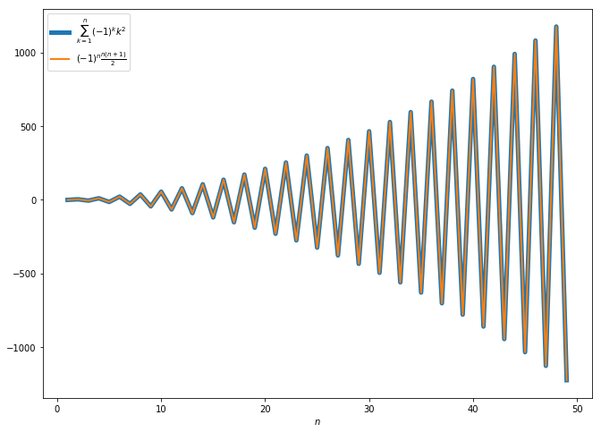

```python
aufgabe1()
```

## HMI H 2015 4a (5 Punkte)

Beweisen Sie, dass fur alle $\forall n ∈ \mathbb{N}$ $$ 4^n \geq n^2 + 3^n $$ gilt.

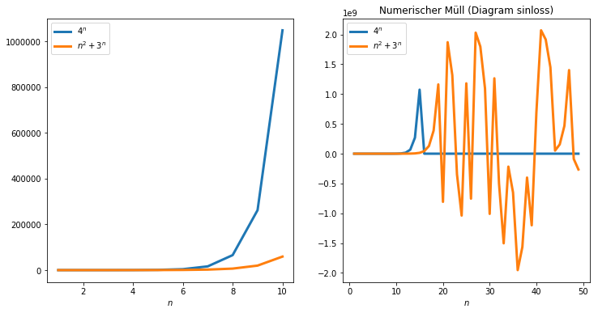

```python
aufgabe2()
```

## HMI F 2015 4a (4 Punkte)

Beweisen Sie, dass fur alle $\forall n ∈ \mathbb{N}$ $$ \sum_{k=1}^n k (k+1) (k+2) = \frac{n (n+1) (n+2) (n+3)}{4} $$ gilt.

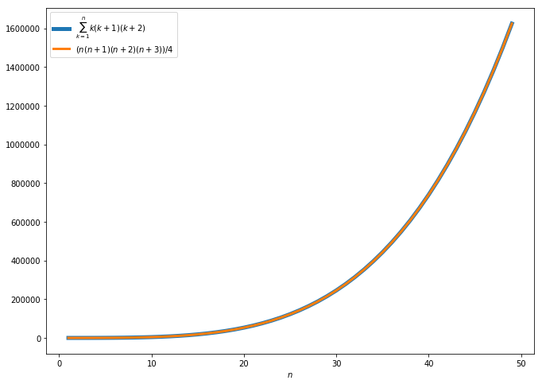

```python
aufgabe3()
```